# NBA Shot Defense Analysis

Aidan Judge

## Exposition for Models 1 & 2:

Defense is a significant factor in any team’s success in the NBA, and players like Kawhi Leonard and Lebron James are praised as being dynamic “two-way” players. Sometimes, however, defensive effects can be challenging to quantify. The average distance of the closest defender on shots will serve as a proxy for the quality of defense contesting the shots in the graphic below. In the two graphs below, I have graphed the relationship between the average distance of the closest defender with the margin of victory first for all games in the 2015 NBA season and then again for the subset of “close games” decided by 8 points or fewer. Both of the summary tables are displayed and show that there is a significant positive relationship between these variables on a 95% confidence interval. For the dataset of all games, if the defenders give the shooters an extra foot of space on average, the margin of victory increases by an estimated 5.851 points. For the dataset of close games decided by 8 points or fewer, if the defenders give the shooters an extra foot of space on average, the margin of victory increases by an estimated 1.4207 points. This means that for every increase in the average distance of the closest defender, the margin of victory increased for the offensive team that was shooting.

# Model 1:

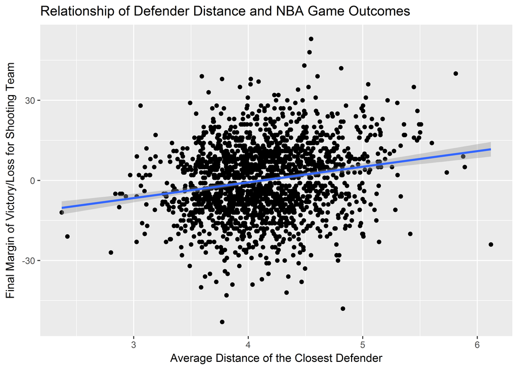

```
##
## Call:
## lm_basic(formula = final_margin_mean ~ 1 + close_def_dist_mean,
##     data = individualgames)
##
## Residuals:
##     Min      1Q  Median      3Q     Max
## -52.105  -8.543   0.347   9.120  50.523
##
## Coefficients:
##                     Estimate   2.5 %  97.5 %
## (Intercept)          -24.137 -29.714 -18.560
## close_def_dist_mean    5.851   4.508   7.195
##
## Residual standard error: 13.28 on 1806 degrees of freedom
## Multiple R-squared:  0.03882,    Adjusted R-squared:  0.03829
## F-statistic: 72.94 on 1 and 1806 DF,  p-value: < 2.2e-16
```

# Model 2:

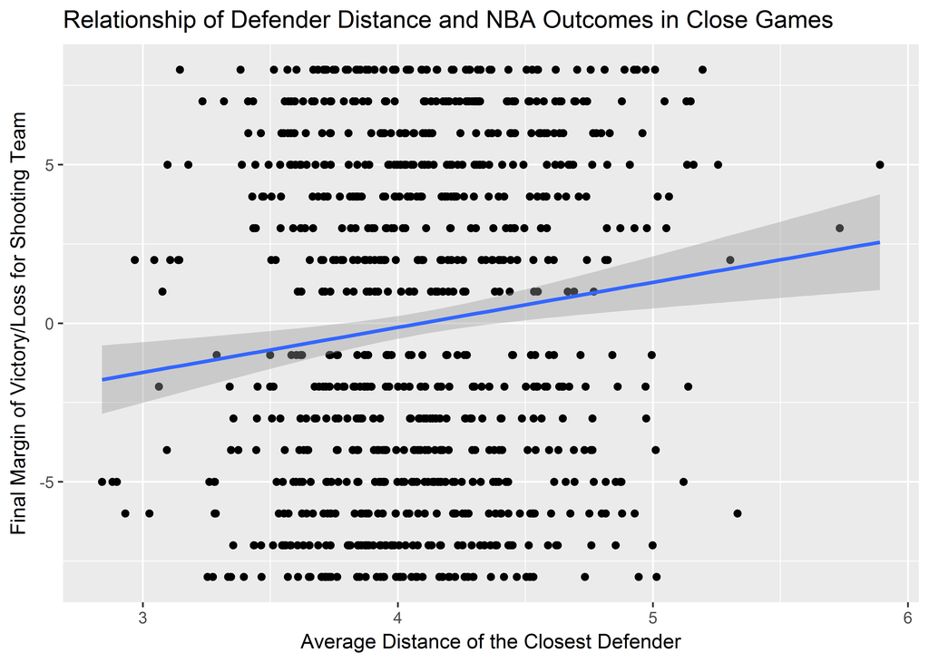

```
##
## Call:
## lm_basic(formula = final_margin_mean ~ 1 + close_def_dist_mean,
##     data = closegames)
##
## Residuals:
##     Min      1Q  Median      3Q     Max
## -9.3117 -4.9103  0.0879  4.9375  9.3438
##
## Coefficients:
##                     Estimate   2.5 % 97.5 %
## (Intercept)          -5.8114 -9.1642 -2.459
## close_def_dist_mean   1.4207  0.6056  2.236
##
## Residual standard error: 5.287 on 864 degrees of freedom
## Multiple R-squared:  0.01336,    Adjusted R-squared:  0.01222
## F-statistic:  11.7 on 1 and 864 DF,  p-value: 0.0006534
```

## Exposition for Models 3 & 4:

With that being said, it is worthwhile to consider whether this statistic is always a good proxy for the quality of defense. In the third graph below, I use a subset of the top 100 scorers in the 2015 season to show some of the most “unguardable” players in the NBA. What we find is that the shooters with the highest shooting percentages for the most part are the tallest players, power forwards and centers, who spend the least time with the ball in their hands meaning they shoot quickly and give even physically close defenders no time to position themselves. These players are also the ones who move around the least, and thus, as the fourth graphic shows, actually have defenders guarding them physically the closest. The combination of these two graphs would challenge the original assumption that the average distance of the closest defender from the shooter is a strong proxy for the quality of defense. While that might be true for the shorter guards playing the 1, 2, or 3 position, it is more challenging to quantify defensive quality in close quarters for the big men around the rim. This does not lead me to challenge the hypothesis, but is food for thought on how to best defend different sized players in different positions. Perhaps it could be a good starting point on different defensive formations: box-and-one vs. man-to-man vs. zone defense. I still believe that guarding your opponents closely (i.e. keeping you distance low) will increase your chances of victory, just as making the extra pass on offense to find your most open teammate will increase your chances of victory.

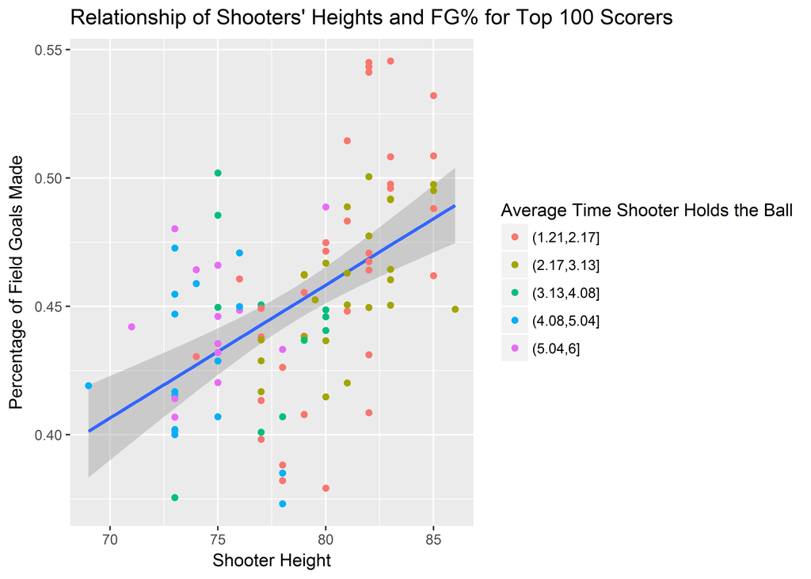

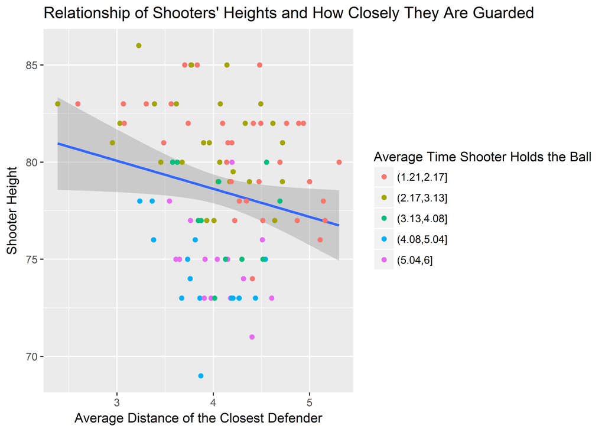